# Practical Machine Learning

Liao, Chen-Fu

June 21, 2015

## Overview

This report is for Practical Machine Learning project. In this project, our goal is to use data from accelerometers on the belt, forearm, arm, and dumbell of 6 participants to predict the manner in which they did the exercise. They were asked to perform barbell lifts correctly and incorrectly in 5 different ways:

exactly according to the specification (Class A)  
throwing the elbows to the front (Class B)  
lifting the dumbbell only halfway (Class C)  
lowering the dumbbell only halfway (Class D)  
throwing the hips to the front (Class E)

## Background

Using devices such as Jawbone Up, Nike FuelBand, and Fitbit it is now possible to collect a large amount of data about personal activity relatively inexpensively. These type of devices are part of the quantified self movement - a group of enthusiasts who take measurements about themselves regularly to improve their health, to find patterns in their behavior, or because they are tech geeks. One thing that people regularly do is quantify how much of a particular activity they do, but they rarely quantify how well they do it. In this project, your goal will be to use data from accelerometers on the belt, forearm, arm, and dumbell of 6 participants. They were asked to perform barbell lifts correctly and incorrectly in 5 different ways. More information is available from the website here: http://groupware.les.inf.puc-rio.br/har (see the section on the Weight Lifting Exercise Dataset).

## Data

The training data for this project are available here: https://d396qusza40orc.cloudfront.net/predmachlearn/pml-training.csv The test data are available here: https://d396qusza40orc.cloudfront.net/predmachlearn/pml-testing.csv The data for this project come from this source:  
http://groupware.les.inf.puc-rio.br/har.

## Set programming environment(Assume that pml-training.csv and pml-testing.csv are already in the working directory.)

```r
#Load libraries
library(caret)
library(randomForest)
```

## Read Data

The original data set has 160 variables (including “classe”).

```r
#Read the training and testing data
train <- read.csv("pml-training.csv", header = T,
                  na.strings=c("NA","","#DIV/0!"))
test <- read.csv("pml-testing.csv", header = T,
                 na.strings=c("NA","","#DIV/0!"))
dim(train)
```

```
## [1] 19622   160
```

```r
dim(test)
```

```
## [1]  20 160
```

## Clean Data

After cleaning, the data set has only 54 variables now (including “classe”).

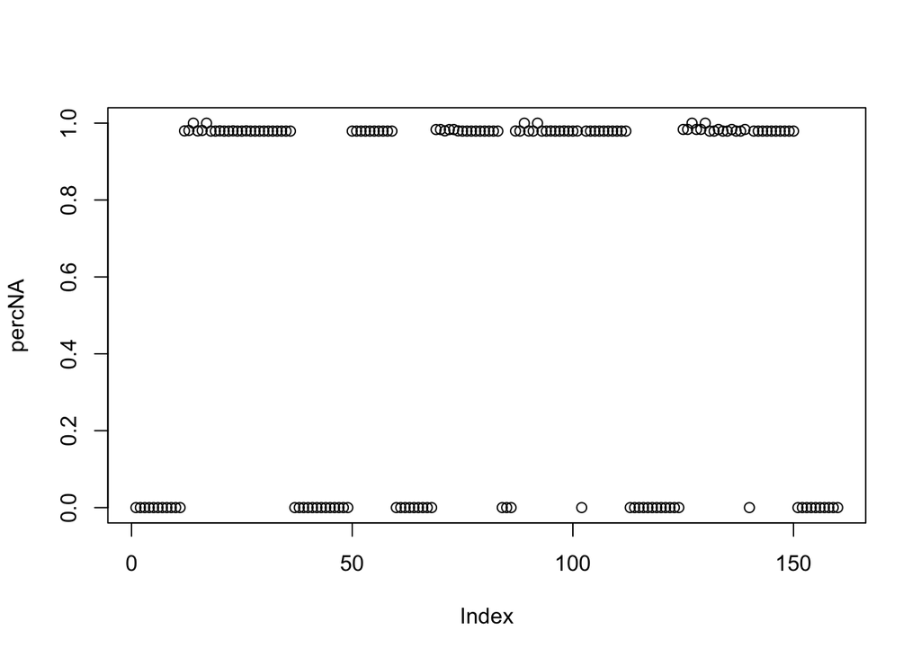

```r
#Cleaning data
#1. Check NA columns
#Check % of NA for every column
percNA <- sapply(1:160, function(i) sum(is.na(train[,i]))/dim(train)[1])

#Show the plot of percNA
plot(percNA)
```

```r
#List all columns for selection and select non-NA columns
#percNA < 0.5 is arbitrary, one can use any number between 0 and 0.9
allCol <- names(train)
nonNACol <- allCol[percNA < 0.5]

#Subset original train dataset for non-NA columns
newTrain <- subset(train, select = nonNACol)

#2. Remove X, timestamp and window columns that are not useful here
newTrain <- newTrain[,!grepl("^X|timestamp|window", names(newTrain))]
dim(newTrain)
```

```
## [1] 19622    54
```

## Split Data

I set the seed for reproducibility and use caret package to split data into training and testing sets.

```r
#Split data into training set and testing set
set.seed(234)
inTrain <- createDataPartition(newTrain$classe, p = 0.7, list = F)
myTrain <- newTrain[inTrain,]
myTest <- newTrain[-inTrain,]
```

## Prediction using Random Forest with 5-fold cross validation

I train the random forest model using the training data set and perform a 5-fold cross validation.

```r
#Train a random forest model with a 5-fold cross validation
tc <- trainControl(method="cv", 5)
modFit <- train(classe ~ ., data = myTrain, method="rf", trControl = tc,
                ntree=250)
modFit
```

```
## Random Forest
##
## 13737 samples
##    53 predictor
##     5 classes: 'A', 'B', 'C', 'D', 'E'
##
## No pre-processing
## Resampling: Cross-Validated (5 fold)
##
## Summary of sample sizes: 10989, 10991, 10989, 10990, 10989
##
## Resampling results across tuning parameters:
##
##   mtry  Accuracy   Kappa      Accuracy SD   Kappa SD
##    2    0.9891537  0.9862785  0.0015067523  0.0019065141
##   29    0.9909005  0.9884887  0.0003647732  0.0004613551
##   57    0.9870423  0.9836058  0.0009827357  0.0012434226
##
## Accuracy was used to select the optimal model using  the largest value.
## The final value used for the model was mtry = 29.
```

## Estimated Out-of-Sample Error Rate

```r
#Apply fitted model to myTest to estimate out-of-sample error rate
predMyTest <- predict(modFit, myTest)
cm <- confusionMatrix(myTest$classe, predMyTest)
cm
```

```
## Confusion Matrix and Statistics
##
##           Reference
## Prediction    A    B    C    D    E
##          A 1672    2    0    0    0
##          B    7 1128    4    0    0
##          C    0    8 1016    2    0
##          D    0    0    9  953    2
##          E    0    1    1    5 1075
##
## Overall Statistics
##
##                Accuracy : 0.993
##                  95% CI : (0.9906, 0.995)
##     No Information Rate : 0.2853
##     P-Value [Acc > NIR] : < 2.2e-16
##
##                   Kappa : 0.9912
##  Mcnemar's Test P-Value : NA
##
## Statistics by Class:
##
##                      Class: A Class: B Class: C Class: D Class: E
## Sensitivity            0.9958   0.9903   0.9864   0.9927   0.9981
## Specificity            0.9995   0.9977   0.9979   0.9978   0.9985
## Pos Pred Value         0.9988   0.9903   0.9903   0.9886   0.9935
## Neg Pred Value         0.9983   0.9977   0.9971   0.9986   0.9996
## Prevalence             0.2853   0.1935   0.1750   0.1631   0.1830
## Detection Rate         0.2841   0.1917   0.1726   0.1619   0.1827
## Detection Prevalence   0.2845   0.1935   0.1743   0.1638   0.1839
## Balanced Accuracy      0.9977   0.9940   0.9922   0.9952   0.9983
```

```r
#Out-of-sample accuracy and out-of-sample error rate
accu <-cm$overall[1]
print(paste("Accuracy is", accu))
```

```
## [1] "Accuracy is 0.99303313508921"
```

```r
oose <- 1 - accu
names(oose) = "oose"
print(paste("Estimated out of sample error is", oose))
```

```
## [1] "Estimated out of sample error is 0.00696686491079013"
```

## Apply the Prediction Model to 20 Testing Data Set

```r
#Apply fitted model to predict the original 20 testing data
result <- predict(modFit, test)
print(result)
```

[output not shown]